# PPCA0026 - Tarefa de Casa 1: Introdução ao Quarto com R

Author

Ítalo Vinícius Pereira Guimarães - 241130529

Published

June 7, 2025

## Introdução

Bem-vindo(a) à primeira tarefa de casa da disciplina PPCA0026!

**Objetivos desta tarefa:**

1. Familiarizar-se com a criação de documentos `.qmd` (Quarto Markdown).
2. Aprender a integrar texto narrativo, blocos de código R e a saída desses blocos (incluindo gráficos e tabelas) em um único arquivo HTML auto-contido.
3. Praticar a criação de visualizações de dados básicas com `ggplot2` e manipulação de dados elementar com `dplyr`, baseando-se nos exemplos da Semana 1, Parte 2 e no Capítulo 1 do livro “R para Ciência de Dados” (R4DS).

**Referência Principal para Quarto:**

- Capítulo 28 do R4DS (tradução para o português): [Quarto - R para Ciência de Dados](https://pt.r4ds.hadley.nz/quarto.html)

**Instruções Gerais:**

- Substitua `"Seu Nome Aqui"` no cabeçalho YAML pelo seu nome completo.
- Complete as seções de código R onde indicado.
- Escreva suas interpretações e respostas textuais onde solicitado.
- Após completar o arquivo `.qmd`, renderize-o para HTML. Certifique-se de que a opção `embed-resources: true` está no cabeçalho YAML para que o HTML seja auto-contido.
- Envie **ambos** os arquivos: o `.qmd` e o `.html` resultante.

## 1. Configuração Inicial

Este primeiro bloco de código carrega os pacotes necessários. A opção de chunk `include: false` significa que o código será executado, mas nem o código nem sua saída aparecerão no documento HTML final. Isso é útil para códigos de configuração.

Agora que o `tidyverse` está carregado, podemos acessar o conjunto de dados `mpg`.

```r
# Vamos dar uma olhada nas primeiras linhas do dataset mpg
# e na sua estrutura para nos familiarizarmos.
head(mpg)
```

```
# A tibble: 6 × 11
  manufacturer model displ  year   cyl trans      drv     cty   hwy fl    class
  <chr>        <chr> <dbl> <int> <int> <chr>      <chr> <int> <int> <chr> <chr>
1 audi         a4      1.8  1999     4 auto(l5)   f        18    29 p     compa…
2 audi         a4      1.8  1999     4 manual(m5) f        21    29 p     compa…
3 audi         a4      2    2008     4 manual(m6) f        20    31 p     compa…
4 audi         a4      2    2008     4 auto(av)   f        21    30 p     compa…
5 audi         a4      2.8  1999     6 auto(l5)   f        16    26 p     compa…
6 audi         a4      2.8  1999     6 manual(m5) f        18    26 p     compa…
```

```r
str(mpg)
```

```
tibble [234 × 11] (S3: tbl_df/tbl/data.frame)
 $ manufacturer: chr [1:234] "audi" "audi" "audi" "audi" ...
 $ model       : chr [1:234] "a4" "a4" "a4" "a4" ...
 $ displ       : num [1:234] 1.8 1.8 2 2 2.8 2.8 3.1 1.8 1.8 2 ...
 $ year        : int [1:234] 1999 1999 2008 2008 1999 1999 2008 1999 1999 2008 ...
 $ cyl         : int [1:234] 4 4 4 4 6 6 6 4 4 4 ...
 $ trans       : chr [1:234] "auto(l5)" "manual(m5)" "manual(m6)" "auto(av)" ...
 $ drv         : chr [1:234] "f" "f" "f" "f" ...
 $ cty         : int [1:234] 18 21 20 21 16 18 18 18 16 20 ...
 $ hwy         : int [1:234] 29 29 31 30 26 26 27 26 25 28 ...
 $ fl          : chr [1:234] "p" "p" "p" "p" ...
 $ class       : chr [1:234] "compact" "compact" "compact" "compact" ...
```

```r
?mpg # Para ver a documentação do dataset
```

## 2. Primeiro Gráfico: Consumo na Estrada vs. Cilindrada

Nesta seção, você criará um gráfico de dispersão para explorar a relação entre a cilindrada do motor (`displ`) e o consumo de combustível na estrada (`hwy`), usando o dataset `mpg`.

**Tarefa:**

1. Crie um gráfico de dispersão (`geom_point`) com `displ` no eixo x e `hwy` no eixo y.
2. Mapeie a variável `class` (tipo de carro) para a estética `color` dos pontos.
3. Adicione um título informativo ao gráfico e rótulos apropriados para os eixos x e y (em português).
4. Escreva uma breve interpretação do gráfico na seção de texto abaixo do bloco de código.

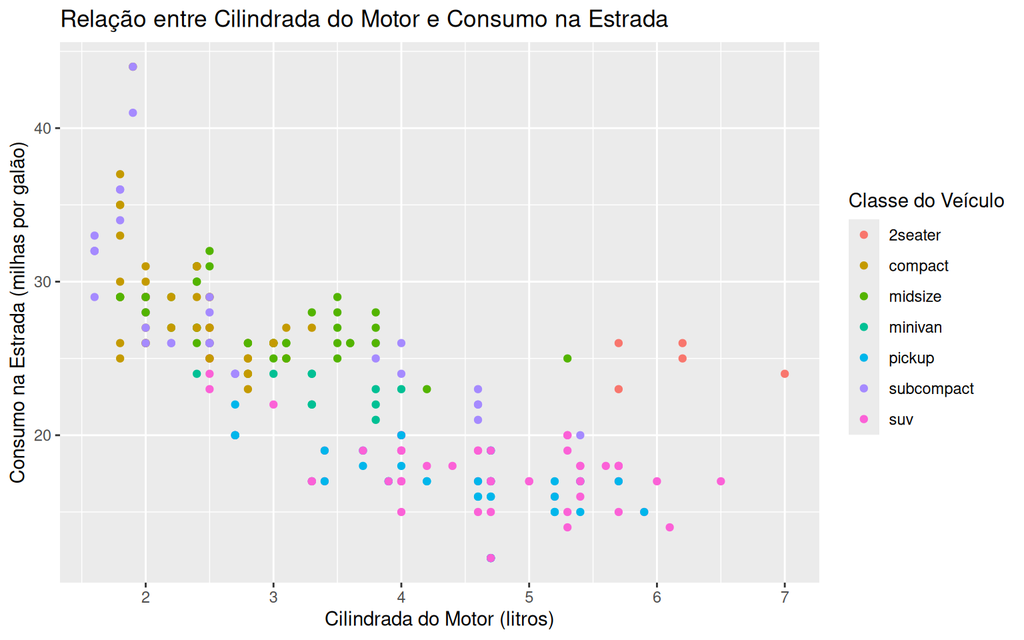

Gráfico de dispersão: Consumo na estrada (hwy) vs. Cilindrada do motor (displ), colorido por classe do veículo.

```r
# Seu código ggplot2 aqui para criar o gráfico de dispersão.
# Lembre-se de usar ggplot(), geom_point() e labs().

ggplot(data = mpg, aes(x = displ, y = hwy, color = class)) +
    geom_point() +
    labs(
        title = "Relação entre Cilindrada do Motor e Consumo na Estrada",
        x = "Cilindrada do Motor (litros)",
        y = "Consumo na Estrada (milhas por galão)",
        color = "Classe do Veículo"
    )
```

**Interpretação do Gráfico de Dispersão:**

*Escreva sua interpretação aqui. O que você observa sobre a relação entre `displ` e `hwy`? Como a `class` do veículo parece influenciar essa relação?*

A análise do gráfico mostra uma forte relação inversa: quanto maior o motor de um carro (displ), menor sua eficiência na estrada (hwy).

Essa tendência é nitidamente segmentada pela class do veículo. De um lado, compactos e subcompactos, com motores pequenos, formam um grupo de alta eficiência. No extremo oposto, SUVs e picapes, com motores grandes, agrupam-se na faixa de baixa eficiência.

Portanto, a categoria do veículo é um fator decisivo, ditando que carros maiores e mais pesados são, previsivelmente, os que mais consomem combustível.

## 3. Adicionando uma Linha de Suavização

Vamos aprimorar o gráfico anterior adicionando uma linha de suavização para visualizar melhor a tendência geral.

**Tarefa:**

1. Copie o código do gráfico anterior.
2. Adicione uma camada `geom_smooth()` ao gráfico. Mantenha o mapeamento de cores por `class` para a linha de suavização também, se desejar (ou crie uma linha de suavização geral).
3. Observe a linha (ou linhas) de suavização. O que ela(s) sugere(m)?

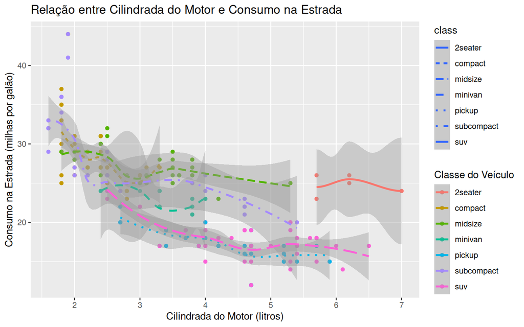

Dispersão de hwy vs. displ com linha de suavização, por classe.

```r
# Seu código ggplot2 aqui (baseado no anterior, adicionando geom_smooth).
# Dica: você pode adicionar geom_smooth() diretamente ao seu código ggplot anterior.
# Considere se quer uma linha de suavização geral ou uma para cada 'class'.

ggplot(data = mpg, aes(x = displ, y = hwy, color = class)) +
    geom_point() +
    suppressWarnings(geom_smooth(aes(linetype = class))) +
    # facet_wrap(~ class, nrow = 2) +
    labs(
        title = "Relação entre Cilindrada do Motor e Consumo na Estrada",
        x = "Cilindrada do Motor (litros)",
        y = "Consumo na Estrada (milhas por galão)",
        color = "Classe do Veículo"
    )
```

**Interpretação da Linha de Suavização:**

*O que a linha de suavização (ou as linhas, se você fez por classe) indica sobre a tendência da relação entre `displ` e `hwy`? A relação parece ser linear?*

## 4. Explorando Consumo com Boxplots

Boxplots são úteis para comparar distribuições de uma variável contínua entre diferentes grupos de uma variável categórica.

**Tarefa:**

1. Crie um boxplot que mostre a distribuição do consumo na estrada (`hwy`) para cada tipo de tração (`drv`).
2. Adicione um título e rótulos apropriados aos eixos (em português).
3. Interprete o boxplot.

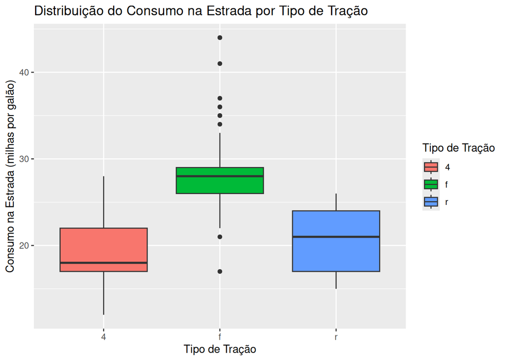

Boxplot do consumo na estrada (hwy) por tipo de tração (drv).

```r
# Seu código ggplot2 aqui para criar o boxplot.
# Use geom_boxplot(). Você pode mapear 'drv' para o preenchimento (fill) também.

ggplot(data = mpg, aes(x = drv, y = hwy, fill = drv)) +
    geom_boxplot() +
    labs(
        title = "Distribuição do Consumo na Estrada por Tipo de Tração",
        x = "Tipo de Tração",
        y = "Consumo na Estrada (milhas por galão)",
        fill = "Tipo de Tração"
    )
```

**Interpretação do Boxplot:**

*Quais tipos de tração (`drv`) tendem a ter maior/menor consumo na estrada (`hwy`)? Existem diferenças notáveis na variabilidade ou presença de outliers entre os grupos?*

Consumo: Veículos com tração dianteira (f) são, em média, os mais eficientes (menor consumo). Em contraste, os veículos com tração 4x4 (4) tendem a ter a menor eficiência (maior consumo).

Variabilidade e Outliers: A tração traseira (r) apresenta a maior variação de eficiência entre seus modelos. O grupo de tração dianteira (f) se destaca pela presença de vários outliers, indicando a existência de carros excepcionalmente econômicos nessa categoria.

## 5. Sumarizando Dados com `dplyr` e Visualizando

Muitas vezes, queremos calcular estatísticas resumo e depois visualizá-las.

**Tarefa:**

1. Use `dplyr` para calcular o consumo médio na cidade (`cty`) para cada fabricante (`manufacturer`).
   - Agrupe os dados por `manufacturer`.
   - Calcule a média de `cty` para cada grupo.
2. Crie um gráfico de colunas (`geom_col`) para visualizar essas médias.
   - Como existem muitos fabricantes, pode ser útil reordenar as barras para melhor visualização (e.g., da maior para a menor média). Dica: use `reorder()` dentro de `aes()`.
3. Adicione um título e rótulos apropriados (em português).
4. Interprete o gráfico.

```r
# Passo 1: Usar dplyr para sumarizar os dados
# Crie um objeto chamado 'sumario_cty_fabricante'
# Use group_by() e summarise() com mean().
# sumario_cty_fabricante <- mpg %>% ...

# Ver o sumário (opcional, mas bom para verificar durante o desenvolvimento)
# print(sumario_cty_fabricante)

# Passo 2: Criar o gráfico de colunas com ggplot2
# Use o 'sumario_cty_fabricante' como dados.
# Use geom_col().
# Para reordenar, use aes(x = reorder(manufacturer, -media_cty), y = media_cty)
# Lembre-se de adicionar labs() e possivelmente theme() para ajustar os rótulos do eixo x.

# Passo 1: Usar dplyr para sumarizar os dados
sumario_cty_fabricante <- mpg %>%
    group_by(manufacturer) %>%
    summarise(media_cty = mean(cty, na.rm = TRUE))

# Ver o sumário (opcional, mas bom para verificar durante o desenvolvimento)
print(sumario_cty_fabricante)
```

```
# A tibble: 15 × 2
   manufacturer media_cty
   <chr>            <dbl>
 1 audi              17.6
 2 chevrolet         15
 3 dodge             13.1
 4 ford              14
 5 honda             24.4
 6 hyundai           18.6
 7 jeep              13.5
 8 land rover        11.5
 9 lincoln           11.3
10 mercury           13.2
11 nissan            18.1
12 pontiac           17
13 subaru            19.3
14 toyota            18.5
15 volkswagen        20.9
```

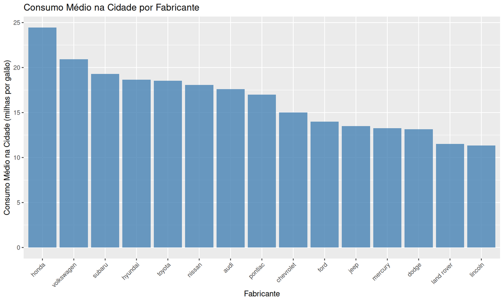

Consumo médio na cidade (cty) por fabricante.

```r
# Passo 2: Criar o gráfico de colunas com ggplot2
ggplot(data = sumario_cty_fabricante, aes(x = reorder(manufacturer, -media_cty), y = media_cty)) +
    geom_col(fill = "steelblue", alpha = 0.8) +
    labs(
        title = "Consumo Médio na Cidade por Fabricante",
        x = "Fabricante",
        y = "Consumo Médio na Cidade (milhas por galão)"
    ) +
    theme(axis.text.x = element_text(angle = 45, hjust = 1))
```

**Interpretação do Gráfico de Colunas:**

*Quais fabricantes têm, em média, o melhor e o pior consumo na cidade? Há alguma surpresa?*

Melhor Consumo: A Honda é a fabricante com a melhor média de consumo na cidade (24.4 mpg). Pior Consumo: A Lincoln apresenta o pior desempenho (11.3 mpg), seguida de perto pela Land Rover (11.5 mpg).

Os resultados são, em grande parte, pouco surpreendentes e alinham-se bem com a reputação das marcas. Não é uma surpresa ver a Honda no topo, conhecida por seus carros compactos e econômicos. Da mesma forma, é esperado que marcas de luxo com veículos grandes e pesados, como Lincoln e Land Rover, fiquem nas últimas posições.

## 6. Tarefas Opcionais (Para Explorar Mais)

Estas tarefas são opcionais e servem para você praticar um pouco mais com `ggplot2` e Quarto.

### Opcional 1: Facetas

Pegue o gráfico de dispersão de `hwy` vs `displ` (tarefa 2 ou 3) e use `facet_wrap(~ cyl)` para criar painéis separados para cada número de cilindros (`cyl`). Como isso muda sua interpretação?

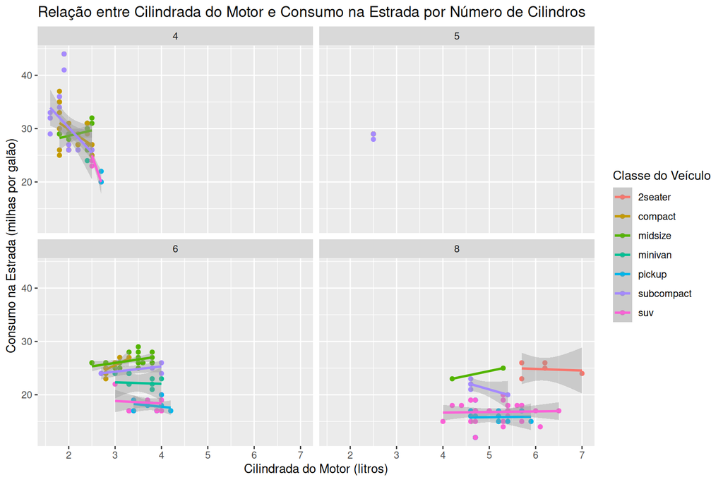

Dispersão de hwy vs. displ, facetado por número de cilindros.

```r
# Seu código aqui (copie e modifique o código da tarefa 2 ou 3)
# Adicione: + facet_wrap(~ cyl, nrow = 2) # ou ncol, como preferir

ggplot(data = mpg, aes(x = displ, y = hwy, color = class)) +
    geom_point() +
    geom_smooth(method = "lm", se = TRUE) +
    facet_wrap(~ cyl, nrow = 2) +
    labs(
        title = "Relação entre Cilindrada do Motor e Consumo na Estrada por Número de Cilindros",
        x = "Cilindrada do Motor (litros)",
        y = "Consumo na Estrada (milhas por galão)",
        color = "Classe do Veículo"
    )
```

*Sua interpretação aqui (se fizer esta tarefa opcional).*

### Opcional 2: Outro `geom`

Experimente usar um `geom` diferente em um dos seus gráficos. Por exemplo:

- Adicione `geom_jitter()` ao seu boxplot da tarefa 4 para ver melhor a distribuição dos pontos.
- Crie um gráfico de violino (`geom_violin`) em vez do boxplot na tarefa 4.

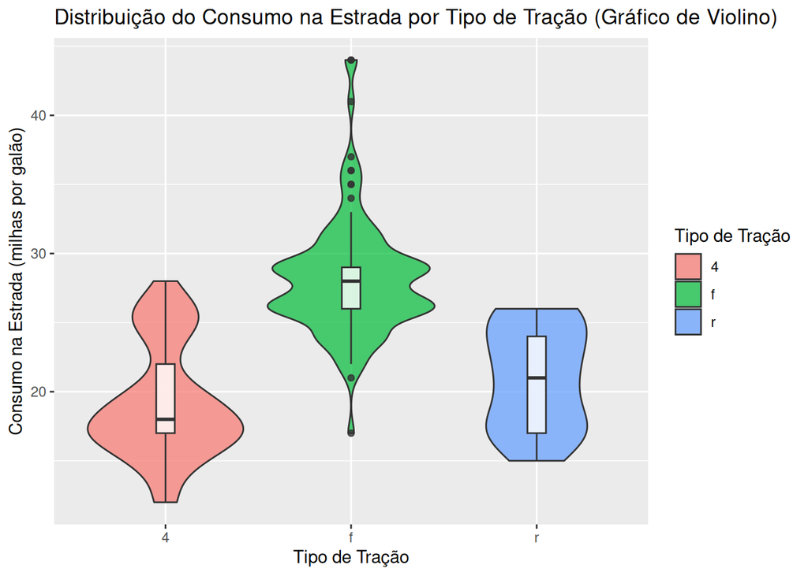

Exemplo de outro geom (e.g., gráfico de violino).

```r
# Seu código aqui (e.g., para geom_violin)

# Gráfico de violino como alternativa ao boxplot
ggplot(data = mpg, aes(x = drv, y = hwy, fill = drv)) +
    geom_violin(alpha = 0.7) +
    geom_boxplot(width = 0.1, fill = "white", alpha = 0.8) +
    labs(
        title = "Distribuição do Consumo na Estrada por Tipo de Tração (Gráfico de Violino)",
        x = "Tipo de Tração",
        y = "Consumo na Estrada (milhas por galão)",
        fill = "Tipo de Tração"
    )
```

*Sua interpretação aqui (se fizer esta tarefa opcional).*

### Opcional 3: Personalização Avançada

Escolha um dos seus gráficos e personalize sua aparência:

- Mude o tema (e.g., `+ theme_bw()`, `+ theme_minimal()`, `+ theme_light()`).
- Altere os títulos da legenda (e.g., `labs(color = "Nova Legenda")`).

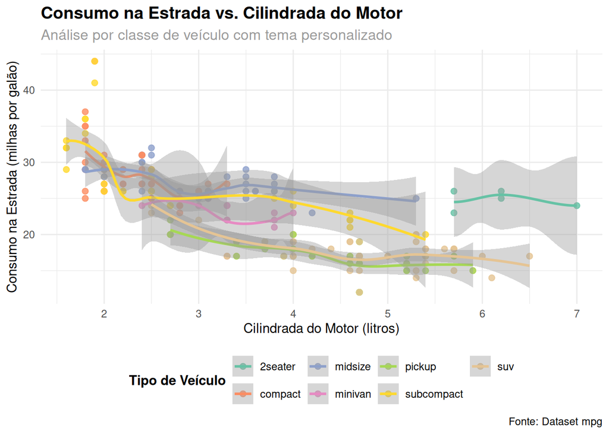

Gráfico com personalização de tema e legenda.

```r
# Seu código aqui

# Personalização do gráfico de dispersão com tema e legenda customizados
ggplot(data = mpg, aes(x = displ, y = hwy, color = class)) +
    geom_point(size = 2, alpha = 0.8) +
    geom_smooth(method = "loess", se = TRUE) +
    labs(
        title = "Consumo na Estrada vs. Cilindrada do Motor",
        subtitle = "Análise por classe de veículo com tema personalizado",
        x = "Cilindrada do Motor (litros)",
        y = "Consumo na Estrada (milhas por galão)",
        color = "Tipo de Veículo",
        caption = "Fonte: Dataset mpg"
    ) +
    theme_minimal() +
    theme(
        plot.title = element_text(size = 14, face = "bold"),
        plot.subtitle = element_text(size = 12, color = "gray60"),
        legend.position = "bottom",
        legend.title = element_text(face = "bold")
    ) +
    scale_color_brewer(type = "qual", palette = "Set2")
```

*Descreva as personalizações que você fez (se fizer esta tarefa opcional).*

### Opcional 4: Interpretação Estendida

Escolha um dos gráficos das tarefas principais e escreva um parágrafo mais detalhado (3-5 frases) sobre os padrões, outliers ou quaisquer outros insights interessantes que você observou.

*Sua interpretação estendida aqui (se fizer esta tarefa opcional).*

### Opcional 5: Ocultando o Código

Crie um gráfico (pode ser um novo ou uma variação de um anterior) onde o código R **não** é mostrado no documento HTML final, mas o gráfico **é** renderizado. (Dica: use a opção de chunk `echo: false`).

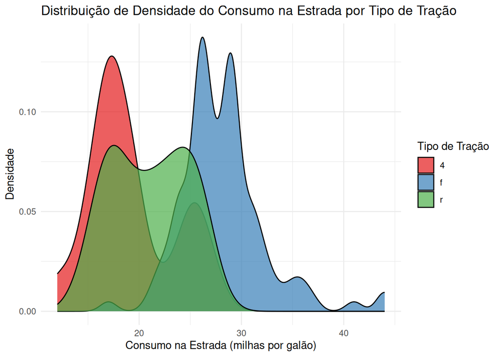

Gráfico gerado com código oculto.

*(Se você fizer esta tarefa, o código acima não aparecerá, mas o gráfico sim, se `eval=TRUE`)*.

## Conclusão e Submissão

Parabéns por completar (ou tentar!) sua primeira tarefa com Quarto!

**Para submeter:**

1. Certifique-se de que seu nome está no cabeçalho YAML.
2. Clique no botão “Render” no RStudio (ou use o comando `quarto render seu_arquivo.qmd` no terminal) para gerar o arquivo HTML.
3. Verifique o arquivo HTML gerado para garantir que tudo aparece como esperado (texto, código, saídas, gráficos).
4. Envie **ambos** os arquivos: `seu_arquivo.qmd` e `seu_arquivo.html`.

Bom trabalho!